# Hackaton Shenouda Gabriel / Lambert Benjamin / DIA 1

Shenouda Gabriel

16/12/2020

```r
library(MASS)
library(caTools)
```

```r
library(rpart.plot)
library(rpart)
library(randomForest)
library(gbm)
library(mlbench)
library(randomForest)
library(caret)
```

## Setup

We have now imported our libraries, let’s import our data : We create a dataset with all the training set and a test set.

By understanding the data set we understand that 3 of the variables describe the track: track’s name, artist, and the target. But track’s name and artist don’t give any information since we won’t be using NLP models or anything like that.

The other 13 columns are the audio features of a track:

```
acousticness.
danceability.
duration_ms.
energy.
instrumentalness.
key.
liveness.
loudness.
mode.
speechiness.
tempo.
time_signature.
valence.
```

```r
dataset <- read.csv('data.csv')
test = read.csv('test.csv')

summary(dataset)
```

```
##   acousticness        danceability     duration_ms          energy
##  Min.   :0.0000028   Min.   :0.1220   Min.   :  16042   Min.   :0.0148
##  1st Qu.:0.0090500   1st Qu.:0.5120   1st Qu.: 199500   1st Qu.:0.5640
##  Median :0.0620000   Median :0.6320   Median : 229093   Median :0.7140
##  Mean   :0.1847794   Mean   :0.6185   Mean   : 245760   Mean   :0.6827
##  3rd Qu.:0.2600000   3rd Qu.:0.7370   3rd Qu.: 270333   3rd Qu.:0.8480
##  Max.   :0.9950000   Max.   :0.9840   Max.   :1004627   Max.   :0.9980
##
##  instrumentalness         key            liveness         loudness
##  Min.   :0.0000000   Min.   : 0.000   Min.   :0.0219   Min.   :-33.097
##  1st Qu.:0.0000000   1st Qu.: 2.000   1st Qu.:0.0923   1st Qu.: -8.372
##  Median :0.0000661   Median : 6.000   Median :0.1270   Median : -6.238
##  Mean   :0.1315299   Mean   : 5.319   Mean   :0.1927   Mean   : -7.046
##  3rd Qu.:0.0510000   3rd Qu.: 9.000   3rd Qu.:0.2510   3rd Qu.: -4.741
##  Max.   :0.9760000   Max.   :11.000   Max.   :0.9530   Max.   : -0.307
##
##       mode        speechiness          tempo        time_signature
##  Min.   :0.000   Min.   :0.02310   Min.   : 47.86   Min.   :1.000
##  1st Qu.:0.000   1st Qu.:0.03750   1st Qu.:100.05   1st Qu.:4.000
##  Median :1.000   Median :0.05550   Median :121.92   Median :4.000
##  Mean   :0.617   Mean   :0.09272   Mean   :121.55   Mean   :3.968
##  3rd Qu.:1.000   3rd Qu.:0.10800   3rd Qu.:137.64   3rd Qu.:4.000
##  Max.   :1.000   Max.   :0.62200   Max.   :219.33   Max.   :5.000
##
##     valence           target         song_title               artist
##  Min.   :0.0348   Min.   :0.0000   Jack   :   3   Drake          :  12
##  1st Qu.:0.2950   1st Qu.:0.0000   River  :   3   Rick Ross      :  12
##  Median :0.4930   Median :1.0000   Acamar :   2   Disclosure     :  11
##  Mean   :0.4963   Mean   :0.5036   Alright:   2   Backstreet Boys:  10
##  3rd Qu.:0.6900   3rd Qu.:1.0000   Annie  :   2   FIDLAR         :   9
##  Max.   :0.9750   Max.   :1.0000   Awake  :   2   WALK THE MOON  :   9
##                                    (Other):1803   (Other)        :1754
```

```r
head(dataset, 5)
```

```
##   acousticness danceability duration_ms energy instrumentalness key liveness
## 1       0.0102        0.833      204600  0.434         0.021900   2   0.1650
## 2       0.1990        0.743      326933  0.359         0.006110   1   0.1370
## 3       0.0344        0.838      185707  0.412         0.000234   2   0.1590
## 4       0.6040        0.494      199413  0.338         0.510000   5   0.0922
## 5       0.1800        0.678      392893  0.561         0.512000   5   0.4390
##   loudness mode speechiness   tempo time_signature valence target
## 1   -8.795    1      0.4310 150.062              4   0.286      1
## 2  -10.401    1      0.0794 160.083              4   0.588      1
## 3   -7.148    1      0.2890  75.044              4   0.173      1
## 4  -15.236    1      0.0261  86.468              4   0.230      1
## 5  -11.648    0      0.0694 174.004              4   0.904      1
##       song_title           artist
## 1       Mask Off           Future
## 2        Redbone Childish Gambino
## 3   Xanny Family           Future
## 4 Master Of None      Beach House
## 5 Parallel Lines      Junior Boys
```

```r
dataset = dataset[,-c(15,16)]
summary(dataset)
```

```
##   acousticness        danceability     duration_ms          energy
##  Min.   :0.0000028   Min.   :0.1220   Min.   :  16042   Min.   :0.0148
##  1st Qu.:0.0090500   1st Qu.:0.5120   1st Qu.: 199500   1st Qu.:0.5640
##  Median :0.0620000   Median :0.6320   Median : 229093   Median :0.7140
##  Mean   :0.1847794   Mean   :0.6185   Mean   : 245760   Mean   :0.6827
##  3rd Qu.:0.2600000   3rd Qu.:0.7370   3rd Qu.: 270333   3rd Qu.:0.8480
##  Max.   :0.9950000   Max.   :0.9840   Max.   :1004627   Max.   :0.9980
##  instrumentalness         key            liveness         loudness
##  Min.   :0.0000000   Min.   : 0.000   Min.   :0.0219   Min.   :-33.097
##  1st Qu.:0.0000000   1st Qu.: 2.000   1st Qu.:0.0923   1st Qu.: -8.372
##  Median :0.0000661   Median : 6.000   Median :0.1270   Median : -6.238
##  Mean   :0.1315299   Mean   : 5.319   Mean   :0.1927   Mean   : -7.046
##  3rd Qu.:0.0510000   3rd Qu.: 9.000   3rd Qu.:0.2510   3rd Qu.: -4.741
##  Max.   :0.9760000   Max.   :11.000   Max.   :0.9530   Max.   : -0.307
##       mode        speechiness          tempo        time_signature
##  Min.   :0.000   Min.   :0.02310   Min.   : 47.86   Min.   :1.000
##  1st Qu.:0.000   1st Qu.:0.03750   1st Qu.:100.05   1st Qu.:4.000
##  Median :1.000   Median :0.05550   Median :121.92   Median :4.000
##  Mean   :0.617   Mean   :0.09272   Mean   :121.55   Mean   :3.968
##  3rd Qu.:1.000   3rd Qu.:0.10800   3rd Qu.:137.64   3rd Qu.:4.000
##  Max.   :1.000   Max.   :0.62200   Max.   :219.33   Max.   :5.000
##     valence           target
##  Min.   :0.0348   Min.   :0.0000
##  1st Qu.:0.2950   1st Qu.:0.0000
##  Median :0.4930   Median :1.0000
##  Mean   :0.4963   Mean   :0.5036
##  3rd Qu.:0.6900   3rd Qu.:1.0000
##  Max.   :0.9750   Max.   :1.0000
```

```r
head(dataset, 5)
```

```
##   acousticness danceability duration_ms energy instrumentalness key liveness
## 1       0.0102        0.833      204600  0.434         0.021900   2   0.1650
## 2       0.1990        0.743      326933  0.359         0.006110   1   0.1370
## 3       0.0344        0.838      185707  0.412         0.000234   2   0.1590
## 4       0.6040        0.494      199413  0.338         0.510000   5   0.0922
## 5       0.1800        0.678      392893  0.561         0.512000   5   0.4390
##   loudness mode speechiness   tempo time_signature valence target
## 1   -8.795    1      0.4310 150.062              4   0.286      1
## 2  -10.401    1      0.0794 160.083              4   0.588      1
## 3   -7.148    1      0.2890  75.044              4   0.173      1
## 4  -15.236    1      0.0261  86.468              4   0.230      1
## 5  -11.648    0      0.0694 174.004              4   0.904      1
```

```r
test = test[,-c(14,15)]
summary(test)
```

```
##   acousticness        danceability    duration_ms         energy
##  Min.   :0.0000185   Min.   :0.220   Min.   : 82893   Min.   :0.0288
##  1st Qu.:0.0178750   1st Qu.:0.524   1st Qu.:205020   1st Qu.:0.5517
##  Median :0.0760000   Median :0.615   Median :230740   Median :0.7225
##  Mean   :0.2131247   Mean   :0.618   Mean   :251271   Mean   :0.6716
##  3rd Qu.:0.3125000   3rd Qu.:0.741   3rd Qu.:270613   3rd Qu.:0.8117
##  Max.   :0.9950000   Max.   :0.927   Max.   :745653   Max.   :0.9920
##  instrumentalness         key            liveness         loudness
##  Min.   :0.0000000   Min.   : 0.000   Min.   :0.0188   Min.   :-31.367
##  1st Qu.:0.0000000   1st Qu.: 2.000   1st Qu.:0.0919   1st Qu.: -8.733
##  Median :0.0001555   Median : 6.000   Median :0.1185   Median : -6.439
##  Mean   :0.1492353   Mean   : 5.555   Mean   :0.1736   Mean   : -7.442
##  3rd Qu.:0.0816250   3rd Qu.: 9.000   3rd Qu.:0.1857   3rd Qu.: -4.821
##  Max.   :0.9640000   Max.   :11.000   Max.   :0.9690   Max.   : -1.723
##       mode       speechiness          tempo        time_signature
##  Min.   :0.00   Min.   :0.02390   Min.   : 65.23   Min.   :3.000
##  1st Qu.:0.00   1st Qu.:0.03750   1st Qu.:101.26   1st Qu.:4.000
##  Median :1.00   Median :0.04860   Median :120.15   Median :4.000
##  Mean   :0.57   Mean   :0.09212   Mean   :122.13   Mean   :3.975
##  3rd Qu.:1.00   3rd Qu.:0.09065   3rd Qu.:137.86   3rd Qu.:4.000
##  Max.   :1.00   Max.   :0.81600   Max.   :199.73   Max.   :5.000
##     valence
##  Min.   :0.0397
##  1st Qu.:0.3010
##  Median :0.4835
##  Mean   :0.5018
##  3rd Qu.:0.6975
##  Max.   :0.9920
```

```r
head(test, 5)
```

```
##   acousticness danceability duration_ms energy instrumentalness key liveness
## 1       0.2240        0.752      437293 0.7670         9.31e-01   5   0.0833
## 2       0.0648        0.855      310907 0.6380         0.00e+00   9   0.1620
## 3       0.0300        0.350      313707 0.8440         0.00e+00   1   0.1770
## 4       0.9670        0.384      206040 0.0544         9.64e-01   0   0.1150
## 5       0.0145        0.716      215253 0.9720         3.22e-05   7   0.3170
##   loudness mode speechiness   tempo time_signature valence
## 1   -8.022    0      0.0469 117.973              4   0.564
## 2   -4.968    0      0.1430 122.967              4   0.433
## 3   -4.161    0      0.0438 114.640              4   0.107
## 4  -19.791    1      0.0485 181.262              3   0.301
## 5   -2.302    1      0.1960 110.026              4   0.566
```

## We have a function in order to calculate the accuracy, here it is :

```r
PredAccuracy = function(testVal,predVal){
  cm=table(testVal,predVal)
  TN=cm[1,1]
  FP=cm[1,2]
  FN=cm[2,1]
  TP=cm[2,2]
  Accuracy = (TP+TN)/(TP+FP+FN+TN)
  return (Accuracy)
}
```

## Here is a corelation map in order to better understand our data.

But we still tried to drop Loudness since it is a bit correlated with some values. The results are in the end, we tried it with a random forest model since it is our best model accuracy.

```r
cormat <- round(cor(dataset),2)
head(cormat)
```

```
##                  acousticness danceability duration_ms energy instrumentalness
## acousticness             1.00        -0.19        0.08  -0.64             0.13
## danceability            -0.19         1.00       -0.01   0.03            -0.14
## duration_ms              0.08        -0.01        1.00  -0.16             0.30
## energy                  -0.64         0.03       -0.16   1.00            -0.11
## instrumentalness         0.13        -0.14        0.30  -0.11             1.00
## key                     -0.06         0.02        0.02   0.07             0.00
##                    key liveness loudness  mode speechiness tempo time_signature
## acousticness     -0.06    -0.11    -0.56  0.05       -0.09 -0.13          -0.20
## danceability      0.02    -0.15     0.10 -0.04        0.15 -0.14           0.12
## duration_ms       0.02     0.01    -0.28 -0.07       -0.08 -0.08          -0.05
## energy            0.07     0.22     0.76 -0.06        0.09  0.17           0.19
## instrumentalness  0.00     0.01    -0.34 -0.04       -0.15  0.00          -0.07
## key               1.00     0.05     0.04 -0.20        0.02  0.04           0.04
##                  valence target
## acousticness       -0.15  -0.12
## danceability        0.43   0.18
## duration_ms        -0.13   0.14
## energy              0.27   0.02
## instrumentalness   -0.21   0.16
## key                 0.02   0.02
```

```r
library(reshape2)
melted_cormat <- melt(cormat)
head(melted_cormat)
```

```
##               Var1         Var2 value
## 1     acousticness acousticness  1.00
## 2     danceability acousticness -0.19
## 3      duration_ms acousticness  0.08
## 4           energy acousticness -0.64
## 5 instrumentalness acousticness  0.13
## 6              key acousticness -0.06
```

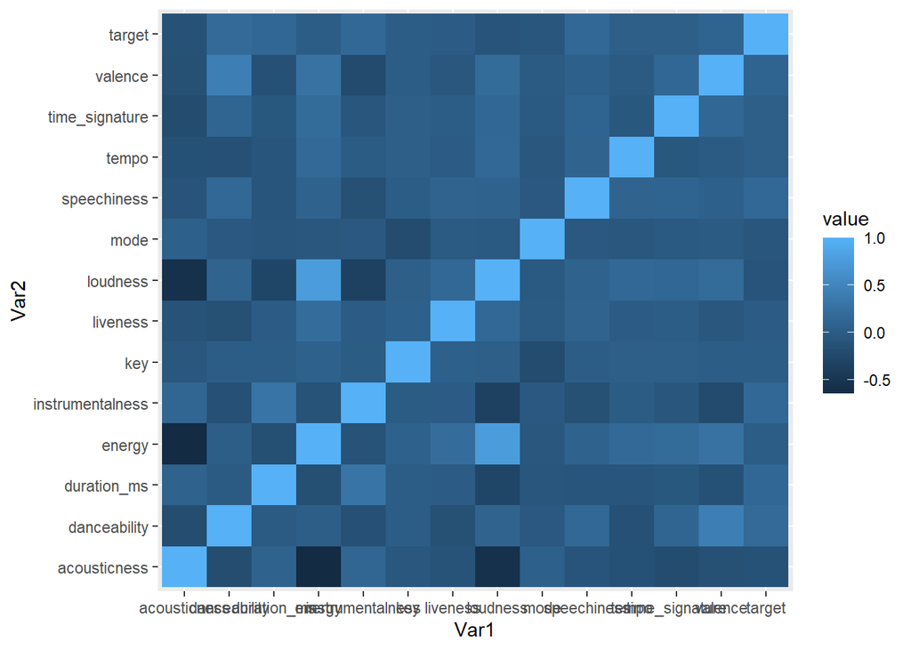

```r
library(ggplot2)
ggplot(data = melted_cormat, aes(x=Var1, y=Var2, fill=value)) +
  geom_tile()
```

## Since our target variable is “0” or “1” we are in the case of a classification problem We will perform the state-of-the-art methods in order to find the best accuracy Our metric is the accuracy since it is the metric on which we are evaluated. ## We will also create a train_set and a test_set based on the data set just in case we need it.

```r
split=sample.split(dataset$target, SplitRatio = 0.75)
train_set=subset(dataset, split==T)
test_set=subset(dataset, split==F)
```

## To be clear on the way we proceeded, we tested models either on the full training set called “dataset” and tested it on the same set (which didn’t give an absolute value (accuracy) but a relative one compared to the other models) or we used our training_set and test_set.

## To give you a cleaner report, we use the training_set and test_set to demonstrate the models, but remember that we apply them in reality on the full dataset when we printed the csv test that we upload on Kaggle.

## It means we cannot reproduce the accuracy given on Kaggle, but you can by using our models tuned with the full “dataset” variable.

## First model we tried was GBM (Gradient boosting or Stochastic Gradient Boosting)

1. n.trees – Number of trees (the number of gradient boosting iteration) i.e. N. Increasing N reduces the error on training set, but setting it too high may lead to over-fitting.
2. interaction.depth (Maximum nodes per tree) - number of splits it has to perform on a tree (starting from a single node).
3. Shrinkage (Learning Rate) – It is considered as a learning rate.
4. n.minobsinnode - the minimum number of observations in trees’ terminal nodes. Set n.minobsinnode = 10. When working with small training samples it may be vital to lower this setting to five or even three.

```r
library(gbm)
gbmClassifier1 = gbm(target ~ ., data = train_set, distribution = "bernoulli", n.trees = 4500, interaction.depth = 5, shrinkage = 0.1, n.minobsinnode = 2)
predictBoost1 = predict(gbmClassifier1, newdata = test_set, type='response')
```

```
## Using 4500 trees...
```

```r
pred_01=ifelse(predictBoost1>0.5,1,0)
acc = PredAccuracy(test_set$target, pred_01)
print(acc)
```

```
## [1] 0.7758242
```

```r
#gbmClassifier1 = gbm(target ~ ., data = dataset, distribution = "bernoulli", n.trees = 4500, interaction.depth = 5, shrinkage = 0.1, n.minobsinnode = 2)
#predictBoost1 = predict(gbmClassifier1, newdata = test, type='response')
#pred_01=ifelse(predictBoost1>0.5,1,0)
#to_be_submitted = data.frame(id = rownames(test), target = pred_01)
#write.csv(to_be_submitted , file = "to_be_submitted1.csv", row.names = F)
```

```r
gbmClassifier2 = gbm(target ~ ., data = train_set, distribution = "bernoulli", n.trees = 7000, interaction.depth = 10, shrinkage = 0.1, n.minobsinnode = 2)
predictBoost2 = predict(gbmClassifier2, newdata = test_set)
```

```
## Using 7000 trees...
```

```r
pred_02=ifelse(predictBoost2>0.5,1,0)
acc = PredAccuracy(test_set$target, pred_02)
print(acc)
```

```
## [1] 0.7714286
```

```r
#gbmClassifier2 = gbm(target ~ ., data = dataset, distribution = "bernoulli", n.trees = 7000, interaction.depth = 10, shrinkage = 0.1, n.minobsinnode = 2)
#predictBoost2 = predict(gbmClassifier2, newdata = test)
#pred_02=ifelse(predictBoost2>0.5,1,0)
#to_be_submitted = data.frame(id = rownames(test), target = predictBoost2)
#write.csv(to_be_submitted , file = "to_be_submitted2.csv", row.names = F)
```

## We will now be using Caret, which allows us to tune the models testing parameters in the range we want. It is very time consuming and i have no time to comput every values we have tested (can take more than 30 min on my computer, so i will just run it with few parametres to show it and show you what parametres i tested but not running them)

```r
fitControl <- trainControl(## 10-fold CV
  method = "repeatedcv",number = 2, #We normally tested it with 10
  repeats = 1) # We normally tested it with 3

gbmGrid <-  expand.grid(interaction.depth = c(10,12,16), n.trees = c(7,8)*1000, shrinkage = 0.1, n.minobsinnode = 2)
# we originally tested it with depth 6, 8, 10, 12, 14, 18, 20 // n.trees : c(4,6)*1000

nrow(gbmGrid)
```

```
## [1] 6
```

```r
train_set$target = as.factor(train_set$target)
test_set$target = as.factor(test_set$target)
gbmClassifier3 <- train(target ~ ., data = train_set, method = "gbm",  trControl = fitControl, verbose = FALSE,
                 ## Now specify the exact models to evaluate:
                 tuneGrid = gbmGrid, metric='Accuracy')
print(gbmClassifier3)
```

```
## Stochastic Gradient Boosting
##
## 1362 samples
##   13 predictor
##    2 classes: '0', '1'
##
## No pre-processing
## Resampling: Cross-Validated (2 fold, repeated 1 times)
## Summary of sample sizes: 681, 681
## Resampling results across tuning parameters:
##
##   interaction.depth  n.trees  Accuracy   Kappa
##   10                 7000     0.7378855  0.4752892
##   10                 8000     0.7408223  0.4810656
##   12                 7000     0.7334802  0.4662378
##   12                 8000     0.7320117  0.4631570
##   16                 7000     0.7173275  0.4333630
##   16                 8000     0.7070485  0.4126038
##
## Tuning parameter 'shrinkage' was held constant at a value of 0.1
##
## Tuning parameter 'n.minobsinnode' was held constant at a value of 2
## Accuracy was used to select the optimal model using the largest value.
## The final values used for the model were n.trees = 8000, interaction.depth
##  = 10, shrinkage = 0.1 and n.minobsinnode = 2.
```

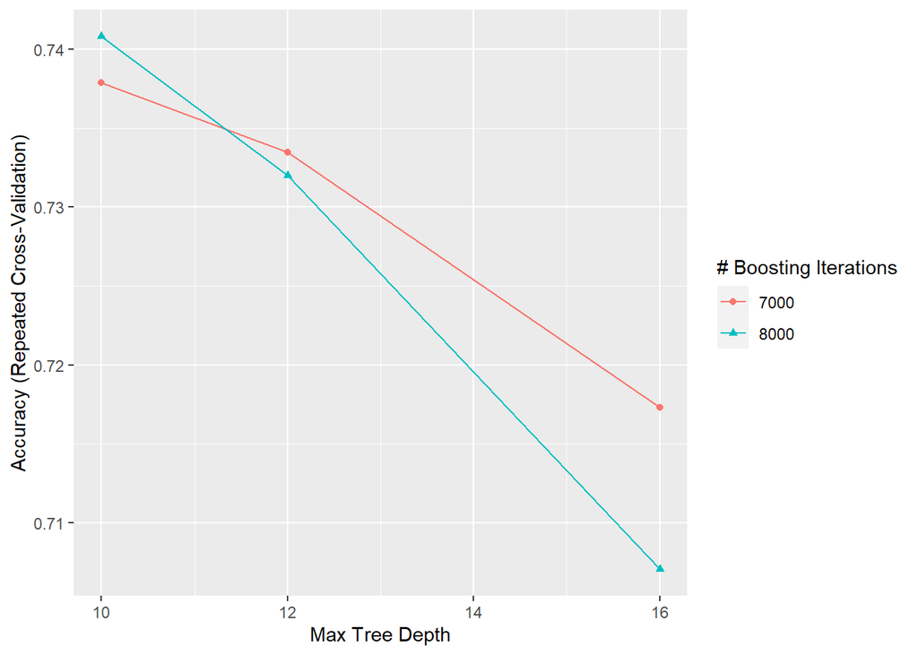

```r
ggplot(gbmClassifier3)
```

```r
pred_03 = predict(gbmClassifier3, newdata = test_set)
er = PredAccuracy(test_set$target, pred_03)
print(er)
```

```
## [1] 0.7714286
```

```r
#gbmClassifier3 <- train(target ~ ., data = dataset, method = "gbm",  trControl = fitControl, verbose = FALSE,
                 ## Now specify the exact models to evaluate:
#                 tuneGrid = gbmGrid, metric='Accuracy')
#print(gbmClassifier3)
#ggplot(gbmClassifier3)
#pred_03 = predict(gbmClassifier3, newdata = test)
#er = PredAccuracy(dataset$target, pred_03)
#print(er)

#to_be_submitted = data.frame(id = rownames(test), target = pred_03)
#write.csv(to_be_submitted , file = "to_be_submitted4.csv", row.names = F)
```

## Now the model that gave us 0.80500 accuracy : Random forest.

We used caret in order to try the 13 mtry values and find the best parameter

```r
control <- trainControl(method="repeatedcv", number=2, repeats=1) #Originally used number=10, repeats=3

tunegrid <- expand.grid(.mtry= (1:13)*1)

rf_default <- train(target~., data=train_set, method="rf", tuneGrid=tunegrid, trControl=control, metric = 'Accuracy')
print(rf_default)
```

```
## Random Forest
##
## 1362 samples
##   13 predictor
##    2 classes: '0', '1'
##
## No pre-processing
## Resampling: Cross-Validated (2 fold, repeated 1 times)
## Summary of sample sizes: 681, 681
## Resampling results across tuning parameters:
##
##   mtry  Accuracy   Kappa
##    1    0.7518355  0.5038058
##    2    0.7657856  0.5316126
##    3    0.7665198  0.5330749
##    4    0.7628488  0.5257485
##    5    0.7635830  0.5272424
##    6    0.7599119  0.5198861
##    7    0.7657856  0.5316317
##    8    0.7591777  0.5184134
##    9    0.7577093  0.5154576
##   10    0.7525698  0.5051937
##   11    0.7496329  0.4993093
##   12    0.7518355  0.5037185
##   13    0.7481645  0.4963834
##
## Accuracy was used to select the optimal model using the largest value.
## The final value used for the model was mtry = 3.
```

```r
predForest = predict(rf_default, newdata = test_set)
c = PredAccuracy(test_set$target, predForest)
print(c)
```

```
## [1] 0.7868132
```

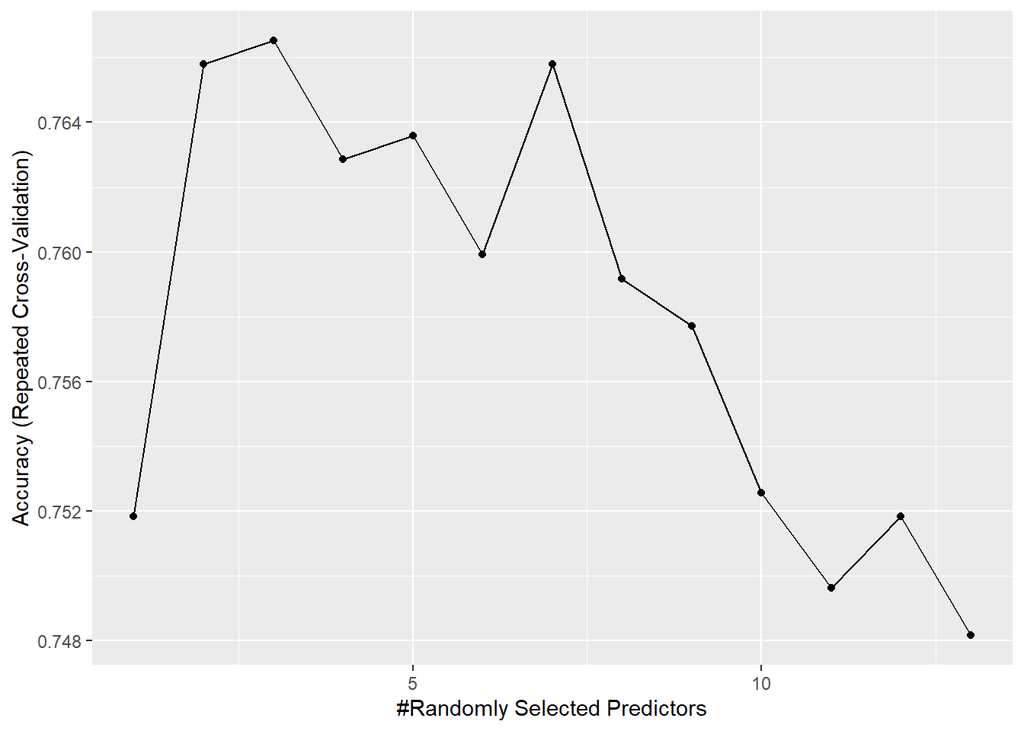

```r
ggplot(rf_default)
```

```r
#f_default <- train(target~., data=dataset, method="rf", tuneGrid=tunegrid, trControl=control, metric = 'Accuracy')
#print(rf_default)

#predForest = predict(rf_default, newdata = test)
#c = PredAccuracy(dataset$target, predForest)
#print(c)
#to_be_submitted = data.frame(id = rownames(test), target = predForest)
#write.csv(to_be_submitted , file = "to_be_submitted4.csv", row.names = F)
```

We tried many couple of values and the results were always different, sometimes the first model was the best, sometimes the last one.

```r
data_forest = randomForest(target ~., data = train_set, mtry = 4, importance = TRUE, ntrees = 2000)

predForestTEST = predict(data_forest, newdata = test_set)
c = PredAccuracy(test_set$target, predForestTEST)
print(c)
```

```
## [1] 0.7846154
```

```r
data_forest = randomForest(target ~., data = train_set, mtry = 7, importance = TRUE, ntrees = 2000)

predForestTEST = predict(data_forest, newdata = test_set)
c = PredAccuracy(test_set$target, predForestTEST)
print(c)
```

```
## [1] 0.7868132
```

```r
data_forest = randomForest(target ~., data = train_set, mtry = 7, importance = TRUE, ntrees = 4000)

predForestTEST = predict(data_forest, newdata = test_set)
c = PredAccuracy(test_set$target, predForestTEST)
print(c)
```

```
## [1] 0.789011
```

```r
data_forest = randomForest(target ~., data = train_set, mtry = 7, importance = TRUE, ntrees = 6000)

predForestTEST = predict(data_forest, newdata = test_set)
c = PredAccuracy(test_set$target, predForestTEST)
print(c)
```

```
## [1] 0.778022
```

```r
#data_forest = randomForest(target ~., data = dataset, mtry = 4, importance = TRUE, ntrees = 2000)
#predForestTEST = predict(data_forest, newdata = test)
#to_be_submitted = data.frame(id = rownames(test), target = predForestTEST)
#write.csv(to_be_submitted , file = "to_be_submitted7777.csv", row.names = F)
```

## We also tried a Boosted Logistic Regression w TUNING MODEL but the accuracy was so bad compared to random forest that we didn’t try it on Kaggle

```r
metric <- "Accuracy"
control <- trainControl(method="repeatedcv", number=2, repeats=1, search="random") # Originaly number=10, repeats=3
model_rpart <- train(target ~., data=train_set, method='LogitBoost', metric=metric, tuneLength=10, trControl=control) #We originally triedtuneLength=20
print(model_rpart)
```

```
## Boosted Logistic Regression
##
## 1362 samples
##   13 predictor
##    2 classes: '0', '1'
##
## No pre-processing
## Resampling: Cross-Validated (2 fold, repeated 1 times)
## Summary of sample sizes: 681, 681
## Resampling results across tuning parameters:
##
##   nIter  Accuracy   Kappa
##    5     0.6813510  0.3617037
##    8     0.7586190  0.4970615
##   19     0.6674009  0.3350493
##   23     0.6872247  0.3742552
##   42     0.7219614  0.4438687
##   61     0.6710720  0.3425630
##   63     0.6762115  0.3527923
##   65     0.6864905  0.3730163
##   67     0.6754772  0.3506678
##   78     0.7228526  0.4452146
##
## Accuracy was used to select the optimal model using the largest value.
## The final value used for the model was nIter = 8.
```

```r
predLogitBoost = predict(model_rpart, newdata = test_set)
acc = PredAccuracy(test_set$target, predLogitBoost)
print(acc)
```

```
## [1] 0.7475728
```

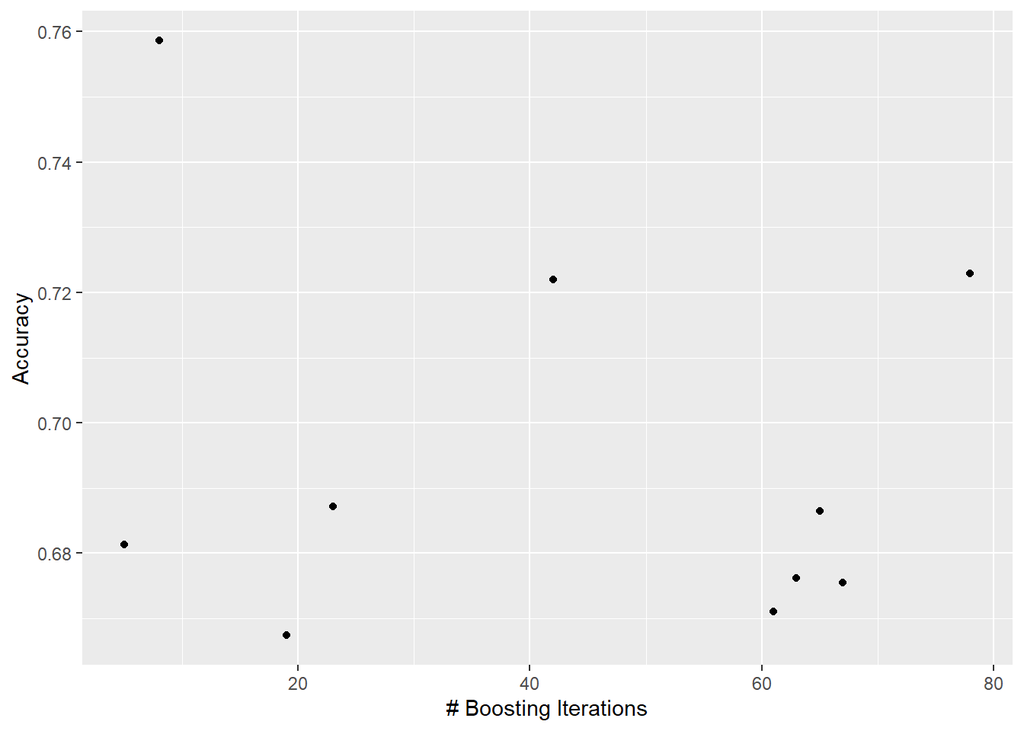

```r
ggplot(model_rpart)
```

```r
#model_rpart <- train(target ~., data=dataset, method='LogitBoost', metric=metric, tuneLength=10, trControl=control)
#print(model_rpart)
#predLogitBoost = predict(model_rpart, newdata = test)
#to_be_submitted = data.frame(id = rownames(test), target = predLogitBoost)
#write.csv(to_be_submitted , file = "to_be_submitted5.csv", row.names = F)
```

## We also tried XGB model, but didn’t end up beating random forest accuracy. XGB stands for eXtreme Gradient Boosting, it has many parameters :

```
nrounds (# Boosting Iterations)
max_depth (Max Tree Depth)
eta (Shrinkage)
gamma (Minimum Loss Reduction)
subsample (Subsample Percentage)
colsample_bytree (Subsample Ratio of Columns)
rate_drop (Fraction of Trees Dropped)
skip_drop (Prob. of Skipping Drop-out)
min_child_weight (Minimum Sum of Instance Weight)
cv (means cross validation)
```

```r
fitControl <- trainControl( method = "cv", number = 2)
xgbGrid <-  expand.grid(nrounds = c(14,16,20,24), max_depth = c(8,10,14,20), eta = 0.1, gamma = 0, colsample_bytree=1, min_child_weight=1, subsample = c(.5,.3,.8,1))
nrow(gbmGrid)
```

```
## [1] 6
```

```r
xgb <- train(target ~ ., data = train_set, method = "xgbTree",  trControl = fitControl, verbose = FALSE,
                 ## Now specify the exact models to evaluate:
                 tuneGrid = xgbGrid, metric='Accuracy')
print(xgb)
```

```
## eXtreme Gradient Boosting
##
## 1362 samples
##   13 predictor
##    2 classes: '0', '1'
##
## No pre-processing
## Resampling: Cross-Validated (2 fold)
## Summary of sample sizes: 681, 681
## Resampling results across tuning parameters:
##
##   max_depth  subsample  nrounds  Accuracy   Kappa
##    8         0.3        14       0.7415565  0.4833429
##    8         0.3        16       0.7599119  0.5199411
##    8         0.3        20       0.7525698  0.5052539
```

[output cut: 71 more lines]

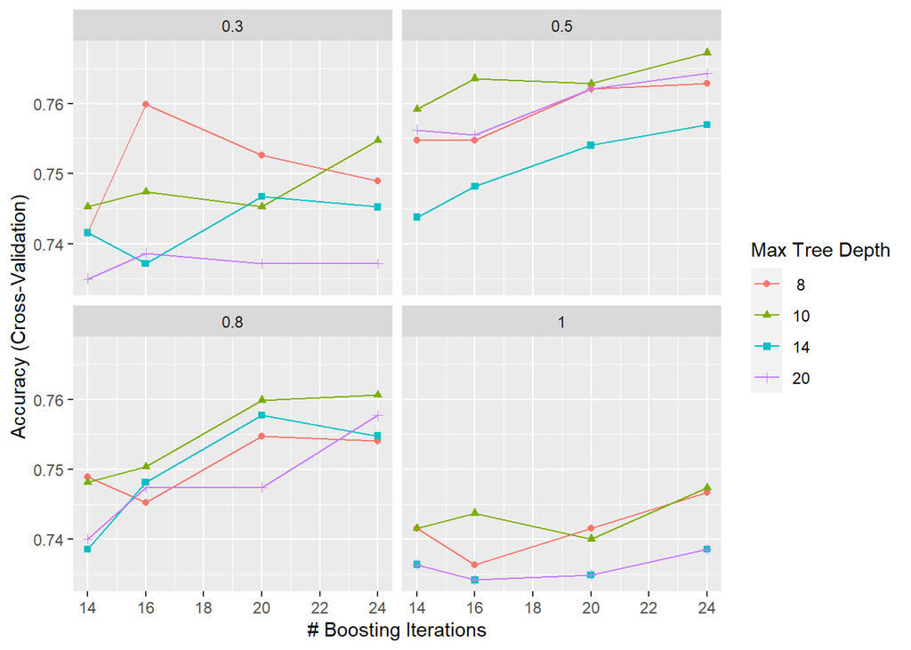

```r
ggplot(xgb)
```

```r
predxgb = predict(xgb, newdata = test_set)
er = PredAccuracy(test_set$target, predxgb)
print(er)
```

```
## [1] 0.7626374
```

```r
#xgb <- train(target ~ ., data = dataset, method = "xgbTree",  trControl = fitControl, verbose = FALSE,
 #                ## Now specify the exact models to evaluate:
  #               tuneGrid = xgbGrid, metric='Accuracy')
#predxgb = predict(xgb, newdata = test)
#to_be_submitted = data.frame(id = rownames(test), target = predxgb)
#write.csv(to_be_submitted , file = "to_be_submittedxgb.csv", row.names = F)
```

## Here we try to do a random forest model without loudness. We obtained the same results using it on Kaggle (0.80500). The results are still random and when we tried it we had only 2 tries left. We might have had a better result with it, who knows…

```r
head(train_set[,-c(8)],5)
```

```
##   acousticness danceability duration_ms energy instrumentalness key liveness
## 1       0.0102        0.833      204600  0.434         2.19e-02   2   0.1650
## 2       0.1990        0.743      326933  0.359         6.11e-03   1   0.1370
## 3       0.0344        0.838      185707  0.412         2.34e-04   2   0.1590
## 4       0.6040        0.494      199413  0.338         5.10e-01   5   0.0922
## 7       0.0145        0.739      241400  0.472         7.27e-06   1   0.2070
##   mode speechiness   tempo time_signature valence target
## 1    1      0.4310 150.062              4   0.286      1
## 2    1      0.0794 160.083              4   0.588      1
## 3    1      0.2890  75.044              4   0.173      1
## 4    1      0.0261  86.468              4   0.230      1
## 7    1      0.1560  80.030              4   0.308      1
```

```r
head(test_set[,-c(8)],5)
```

```
##    acousticness danceability duration_ms energy instrumentalness key liveness
## 5       0.18000        0.678      392893  0.561          0.51200   5    0.439
## 6       0.00479        0.804      251333  0.560          0.00000   8    0.164
## 8       0.02020        0.266      349667  0.348          0.66400  10    0.160
## 9       0.04810        0.603      202853  0.944          0.00000  11    0.342
## 11      0.09150        0.753      324880  0.748          0.00348  10    0.212
##    mode speechiness   tempo time_signature valence target
## 5     0      0.0694 174.004              4   0.904      1
## 6     1      0.1850  85.023              4   0.264      1
## 8     0      0.0371 144.154              4   0.393      1
## 9     0      0.3470 130.035              4   0.398      1
## 11    1      0.0494 104.322              4   0.642      1
```

```r
data_forest2 = randomForest(target ~., data = train_set[,-c(8)], mtry = 4, importance = TRUE, ntrees = 2000)

predForestTEST2 = predict(data_forest2, newdata = test_set[,-c(8)])
c = PredAccuracy(test_set[,-c(8)]$target, predForestTEST2)
print(c)
```

```
## [1] 0.7868132
```

```r
#data_forest2 = randomForest(target ~., data = dataset[,-c(8)], mtry = 4, importance = TRUE, ntrees = 2000)
#predForestTEST2 = predict(data_forest2, newdata = test[,-c(8)])
#predForestTEST3 = ifelse(predForestTEST2 >=0.5, 1, 0)
#to_be_submitted = data.frame(id = rownames(test), target = predForestTEST3)
#write.csv(to_be_submitted , file = "to_be_submitted88888.csv", row.names = F)


data_forest2 = randomForest(target ~., data = train_set[,-c(8)], mtry = 4, importance = TRUE, ntrees = 6000)

predForestTEST2 = predict(data_forest2, newdata = test_set[,-c(8)])
c = PredAccuracy(test_set[,-c(8)]$target, predForestTEST2)
print(c)
```

```
## [1] 0.7824176
```

```r
data_forest2 = randomForest(target ~., data = train_set[,-c(8)], mtry = 7, importance = TRUE, ntrees = 2000)

predForestTEST2 = predict(data_forest2, newdata = test_set[,-c(8)])
c = PredAccuracy(test_set[,-c(8)]$target, predForestTEST2)
print(c)
```

```
## [1] 0.7736264
```

```r
data_forest2 = randomForest(target ~., data = train_set[,-c(8)], mtry = 7, importance = TRUE, ntrees = 6000)

predForestTEST2 = predict(data_forest2, newdata = test_set[,-c(8)])
c = PredAccuracy(test_set[,-c(8)]$target, predForestTEST2)
print(c)
```

```
## [1] 0.7868132
```